# Joining several data frames with `dplyr`

Author

Silvie Cinková

Published

August 9, 2025

# 1 Join tables by a shared column

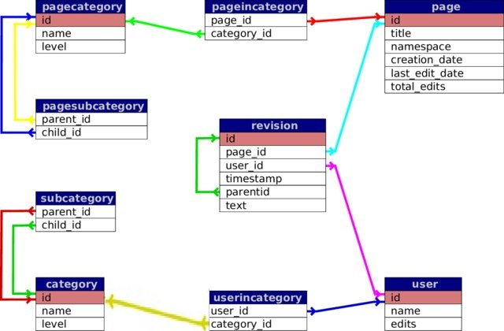

When you want to get a table of titles of the pages and the names of the categories they belong to, you call a function that connects matching rows from the both tables by matching together the values of the primary key and the foreign key. By this way, you do not need to worry about how the rows are arranged in either table.

Designing the architecture of a relational database is a skill in its own right. You need not know exactly how to design a relational database, but you will often need to connect tables from sources that are formed so.

I have adopted this image from this academic paper: https://arxiv.org/pdf/1512.03523. I have corrected the yellow arrow from `userincategory` to `category` to point from `category_id` instead of from `user_id`.

# 2 Revision performed by a user

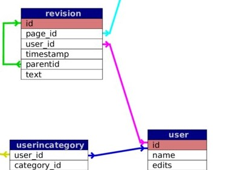

You can even look up things within one single table: look at the `revision` table: `parentid`: the id of the previous revision - to look up on a different row in the same table. I guess that a parent revision is simply the revision event immediately preceding in time.

- Revision table with columns `id`, `page_id`, `user_id`,`timestamp`, , `parentid`,`text`.
- primary key: unique `id` of each revision.
- `page_id` foreign key - turquoise arrow leads to a *page* table, to its primary key (probably called `id` but potentially anything else)
- `user_id` foreign key - purple arrow leads to a *user* table
- `timestamp`: when the revision took place

The scheme does not say whether the parent revision must be one on the same Wikipedia page or rather one performed by the same user. This would also be a design decision: whether you want to be able to track revision of pages or rather the activities of the users, or both. Anyway, from this table, you can connect to both users and pages, so you can generate a table with titles and names of both for each revision.

# 3 `gapminder`

```
# A tibble: 3 × 6
  country     continent  year lifeExp      pop gdpPercap
  <fct>       <fct>     <int>   <dbl>    <int>     <dbl>
1 Afghanistan Asia       1952    28.8  8425333      779.
2 Afghanistan Asia       1957    30.3  9240934      821.
3 Afghanistan Asia       1962    32.0 10267083      853.
```

You can join tables with `dplyr`. So far, we have worked quite a lot with diverse tables from Gapminder.org. You correctly anticipate that Gapminder.org stores its data in relational databases. Their tables are made for you to freely combine information across different tables.

In this session, we will enrich our familiar `gapminder` dataset with additional information from a table of unique countries. We will call that other table `geo`. This table contains many columns, so we will only select a few to keep this demonstration overseeable.

**Tip**

Did you know that `readr` allows you to select columns before you even load the data? When you know their names, that is.

# 4 `geo`

```r
geo <- read_csv(glue("https://raw.githubusercontent.com/open-numbers/",
                     "ddf--gapminder--fasttrack/master/",
                     "ddf--entities--geo--country.csv"))
geo <- geo %>% select(country, name, main_religion_2008, income_3groups, world_4region)
glimpse(geo)
```

```
Rows: 273
Columns: 5
$ country            <chr> "abkh", "abw", "afg", "ago", "aia", "akr_a_dhe", "a…
$ name               <chr> "Abkhazia", "Aruba", "Afghanistan", "Angola", "Angu…
$ main_religion_2008 <chr> NA, "christian", "muslim", "christian", "christian"…
$ income_3groups     <chr> NA, "high_income", "low_income", "middle_income", N…
$ world_4region      <chr> "europe", "americas", "asia", "africa", "americas",…
```

Now we have a data frame called `geo`. It lists 273 countries, each only once, and for each country it gives us its dominant religion (snapshot taken in 2008) and to which income group it belongs. The income groups are Gapminder’s own design and obviously refer to the time of creating this dataset. The countries are encoded by their names (column `name`) and by the abbreviations of these names (column `country`).

**Important**

The `gapminder` data frame does not use abbreviations for country names. But even more importantly, its `country` column does not correspond to `country` but to `name` in the `geo` data frame. This is something to keep in mind when we try to join these two tables!

# 5 Countries in `geo` vs. `gapminder`

```r
unique(geo$name) %>% length()
```

```
[1] 273
```

```r
unique(gapminder$country) %>% length()
```

```
[1] 142
```

When we want to join `geo` and `gapminder`, we can apparently use `geo`’s `name` and `gapminder`’s `country` as the *primary key - foreign key* pair.

The first question you must ask when you want to join two tables by a pair of keys is how much overlap they have at all. `geo` contains many more countries than `gapminder`, so much is clear. But it is not given that all of its countries are listed in `geo`! Therefore we do this quick check.

**Note**

You could as well call `distinct` and `pull` on each, but this base-R way is shorter. It accesses a data frame column as a vector and calls the `unique` function, which acts on vectors like `dplyr::distinct` on data frames.

# 6 Little overlap in key column values?

```r
setdiff(gapminder$country, geo$name)
```

```
[1] "Korea, Dem. Rep."   "Korea, Rep."        "Swaziland"
[4] "United Kingdom"     "United States"      "West Bank and Gaza"
[7] "Yemen, Rep."
```

```r
setdiff(geo$name, gapminder$country) %>% length()
```

```
[1] 138
```

`setdiff` tells you which elements of the first vectors are not in the second vector. We see that the `gapminder` data frame is not a full subset of the `geo` data frame. When we enrich `gapminder` with the information from `geo`, some values will be missing. This has no programmatic solution. This is your design decision. Drop these seven countries from `gapminder` because you don’t get the additional information, or live with `NA`s in the new columns? Or you even find the `geo` table more important and only want to enrich with `gapminder`’s `pop`, `lifeExp`, and `gdpPercap` in a given year? For each of your possible decisions, `dplyr` comes with a dedicated `_join` function.

# 7 Control key selection

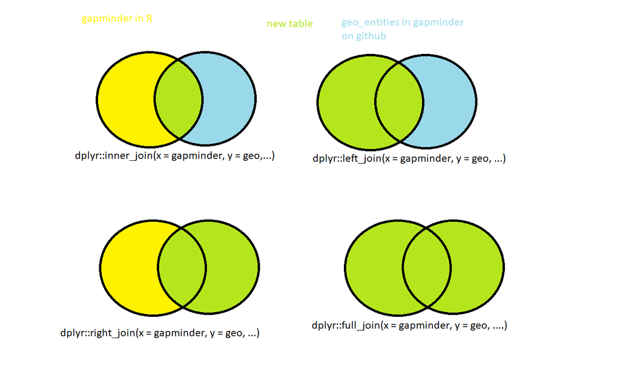

When blue and yellow mix, they give green. This scheme depicts the possible joining outcomes. The yellow area represents the `gapminder` data, the blue the `geo` data, and the green area the resulting new table.

1. With `inner_join` you join just the rows that match in both tables. So you will not have any new empty values.
2. The `left_join` and `right_join` functions are two different perspectives of the same thing, what exactly each does obviously depends on the order in which you feed in the tables. If we always feed `gapminder` as first (the `x` argument) and `geo` second (`y`), left join will keep all rows in `gapminder` and match them to `geo`. We know that seven countries will not be matched, which will result in 7 times 12 rows with `NA` values in the new columns containing the abbreviation, main religion in 2008, and the income group. The twelve comes from the number of observations (remember, 1952 to 2007, in five-year intervals).
3. With `right_join`, we will get a monstrous table of all `geo's countries`, and the ones that match `gapminder`, will be matched twelve times each, with a warning for “many-to-many” relations occurring. The new table is going to have four new columns: `year`, `pop`, `lifeExp`, and `gdpPercap`. They will be filled with `NA` except in the rows with countries whose names matched across both tables, and the seven countries from `gapminder` will not appear in the new table.
4. With `full_join`, no row will be deleted, but there will be `NA` in all mismatched rows.
5. All these tables are going to have the same columns.

# 8 `gapminder` Europe 2007

```r
gapminder_europe <- gapminder %>%
  filter(continent == "Europe", year == 2007) %>%
  select(!c(continent, year))
glimpse(gapminder_europe)
```

```
Rows: 30
Columns: 4
$ country   <fct> "Albania", "Austria", "Belgium", "Bosnia and Herzegovina", "…
$ lifeExp   <dbl> 76.423, 79.829, 79.441, 74.852, 73.005, 75.748, 76.486, 78.3…
$ pop       <int> 3600523, 8199783, 10392226, 4552198, 7322858, 4493312, 10228…
$ gdpPercap <dbl> 5937.030, 36126.493, 33692.605, 7446.299, 10680.793, 14619.2…
```

We make a subset of `gapminder` to keep the data small. Just European countries in 2007 and we drop the columns `continent` and `year` because they are all equal.

# 9 European subset of `geo`

```r
geo_europe <- geo %>% filter(world_4region == "europe") %>%
  select(!world_4region)
glimpse(geo)
```

```
Rows: 273
Columns: 5
$ country            <chr> "abkh", "abw", "afg", "ago", "aia", "akr_a_dhe", "a…
$ name               <chr> "Abkhazia", "Aruba", "Afghanistan", "Angola", "Angu…
$ main_religion_2008 <chr> NA, "christian", "muslim", "christian", "christian"…
$ income_3groups     <chr> NA, "high_income", "low_income", "middle_income", N…
$ world_4region      <chr> "europe", "americas", "asia", "africa", "americas",…
```

# 10 Preferred `gapminder`, intersection

```r
dplyr::inner_join(x = gapminder_europe, y = geo_europe,
                  by = c("country" = "name"))
```

```
# A tibble: 29 × 7
   country  lifeExp    pop gdpPercap country.y main_religion_2008 income_3groups
   <chr>      <dbl>  <int>     <dbl> <chr>     <chr>              <chr>
 1 Albania     76.4 3.60e6     5937. alb       muslim             middle_income
 2 Austria     79.8 8.20e6    36126. aut       christian          high_income
 3 Belgium     79.4 1.04e7    33693. bel       christian          high_income
 4 Bosnia …    74.9 4.55e6     7446. bih       <NA>               middle_income
 5 Bulgaria    73.0 7.32e6    10681. bgr       christian          middle_income
 6 Croatia     75.7 4.49e6    14619. hrv       christian          high_income
 7 Czech R…    76.5 1.02e7    22833. cze       christian          high_income
 8 Denmark     78.3 5.47e6    35278. dnk       christian          high_income
 9 Finland     79.3 5.24e6    33207. fin       christian          high_income
10 France      80.7 6.11e7    30470. fra       christian          high_income
# ℹ 19 more rows
```

We would like to add information from `geo` to `gapminder_europe`.

The resulting data frame is going to inherit only the rows with matching country names from both.

The `_join` functions in `dplyr` always need a first data frame (`x`), a second data frame (`y`), and a vector of column names that provide the key pair(s) in the argument called `by`. The whole thing reads: “Join `x` with `y` by this vector of key pairs.” Each pair contains the name of the key column in `x` and the name of the corresponding column in `y`, in exactly this order. Relational databases are designed to answer most queries with just one pair, but sometimes you need several to uniquely identify observations in at least one of the data frames.

Mind the quotes in the column names in `by`. This time they are mandatory.

There were 30 countries in `gapminder_europe`, but the resulting data frame has only 29 rows. One country was missing in `geo_europe`, although it is so much longer than `gapminder_europe`. We will find out later which. You can see an `NA` in the fourth row, 6th column. This has nothing to do with joining; it was like this in the original `geo_europe` data frame.

Look closely at the names of the columns. Can you see `country` and `country.y`? The former is from `gapminder`, the latter from `geo_europe`. Column names must remain unique, therefore `dplyr` adds suffixes to duplicate names. Typically, the duplicate column name from the `x` data frame gets the suffix `.x` and the other one `.y`. You can replace them with your own suffixes in the `suffix` argument. In this case, only the one from the `y` data frame got the suffix. This is because it was used as a `by` column. By default, the key column from `y` disappears and only the `x` key column stays. You can also fiddle with this in a dedicated argument `keep`. So, in this case, the `x` `country` column stayed, the paired `name` column from `y` vanished, and then `dplyr` spotted another `country` column among the columns inherited from `y`. The function is just written in such a way that it does only put the suffix on one, when the other one was used as key. Do not ponder on it, just remember.

# 11 Keep `gapminder` intact, no matter what.

One country gets `NA` in `geo_europe` columns.

```r
dplyr::left_join(x = gapminder_europe, y = geo_europe,
                 by = c("country" = "name"))
```

```
# A tibble: 30 × 7
   country  lifeExp    pop gdpPercap country.y main_religion_2008 income_3groups
   <chr>      <dbl>  <int>     <dbl> <chr>     <chr>              <chr>
 1 Albania     76.4 3.60e6     5937. alb       muslim             middle_income
 2 Austria     79.8 8.20e6    36126. aut       christian          high_income
 3 Belgium     79.4 1.04e7    33693. bel       christian          high_income
 4 Bosnia …    74.9 4.55e6     7446. bih       <NA>               middle_income
 5 Bulgaria    73.0 7.32e6    10681. bgr       christian          middle_income
 6 Croatia     75.7 4.49e6    14619. hrv       christian          high_income
 7 Czech R…    76.5 1.02e7    22833. cze       christian          high_income
 8 Denmark     78.3 5.47e6    35278. dnk       christian          high_income
 9 Finland     79.3 5.24e6    33207. fin       christian          high_income
10 France      80.7 6.11e7    30470. fra       christian          high_income
# ℹ 20 more rows
```

# 12 Which is missing?

- country mismatch $\rightarrow$ `is.na(country.y)`

```r
dplyr::left_join(x = gapminder_europe, y = geo_europe,
                 by = c("country" = "name")) %>%
  filter(is.na(country.y))
```

```
# A tibble: 1 × 7
  country   lifeExp    pop gdpPercap country.y main_religion_2008 income_3groups
  <chr>       <dbl>  <int>     <dbl> <chr>     <chr>              <chr>
1 United K…    79.4 6.08e7    33203. <NA>      <NA>               <NA>
```

# 13 Focus on `geo_europe`

```r
dplyr::right_join(x = gapminder_europe, y = geo_europe,
                 by = c("country" = "name"))
```

```
# A tibble: 73 × 7
   country  lifeExp    pop gdpPercap country.y main_religion_2008 income_3groups
   <chr>      <dbl>  <int>     <dbl> <chr>     <chr>              <chr>
 1 Albania     76.4 3.60e6     5937. alb       muslim             middle_income
 2 Austria     79.8 8.20e6    36126. aut       christian          high_income
 3 Belgium     79.4 1.04e7    33693. bel       christian          high_income
 4 Bosnia …    74.9 4.55e6     7446. bih       <NA>               middle_income
 5 Bulgaria    73.0 7.32e6    10681. bgr       christian          middle_income
 6 Croatia     75.7 4.49e6    14619. hrv       christian          high_income
 7 Czech R…    76.5 1.02e7    22833. cze       christian          high_income
 8 Denmark     78.3 5.47e6    35278. dnk       christian          high_income
 9 Finland     79.3 5.24e6    33207. fin       christian          high_income
10 France      80.7 6.11e7    30470. fra       christian          high_income
# ℹ 63 more rows
```

# 14 Mismatches in `geo_europe`

```r
dplyr::right_join(x = gapminder_europe, y = geo_europe,
                 by = c("country" = "name")) %>%
  filter(is.na(lifeExp) | is.na(pop) | is.na(gdpPercap))
```

```
# A tibble: 44 × 7
   country   lifeExp   pop gdpPercap country.y main_religion_2008 income_3groups
   <chr>       <dbl> <int>     <dbl> <chr>     <chr>              <chr>
 1 Abkhazia       NA    NA        NA abkh      <NA>               <NA>
 2 Akrotiri…      NA    NA        NA akr_a_dhe <NA>               <NA>
 3 Åland          NA    NA        NA ala       <NA>               <NA>
 4 Andorra        NA    NA        NA and       christian          high_income
 5 Armenia        NA    NA        NA arm       christian          middle_income
 6 Antarcti…      NA    NA        NA ata       <NA>               <NA>
 7 Azerbaij…      NA    NA        NA aze       muslim             middle_income
 8 Belarus        NA    NA        NA blr       christian          middle_income
 9 Channel …      NA    NA        NA chanisl   christian          high_income
10 Czechosl…      NA    NA        NA cheslo    <NA>               <NA>
# ℹ 34 more rows
```

We must look for a column that was not in `geo_europe`. The country column now is the result of `country` and `name`, so it will contain all countries from `geo_europe` but will have dropped `United Kingdom`, which was only in `gapminder_europe`. Any of the numeric columns from `gapminder` will help us though.

# 15 Get what you can

```r
dplyr::full_join(x = gapminder_europe, y = geo_europe,
                 by = c("country" = "name"))
```

```
# A tibble: 74 × 7
   country  lifeExp    pop gdpPercap country.y main_religion_2008 income_3groups
   <chr>      <dbl>  <int>     <dbl> <chr>     <chr>              <chr>
 1 Albania     76.4 3.60e6     5937. alb       muslim             middle_income
 2 Austria     79.8 8.20e6    36126. aut       christian          high_income
 3 Belgium     79.4 1.04e7    33693. bel       christian          high_income
 4 Bosnia …    74.9 4.55e6     7446. bih       <NA>               middle_income
 5 Bulgaria    73.0 7.32e6    10681. bgr       christian          middle_income
 6 Croatia     75.7 4.49e6    14619. hrv       christian          high_income
 7 Czech R…    76.5 1.02e7    22833. cze       christian          high_income
 8 Denmark     78.3 5.47e6    35278. dnk       christian          high_income
 9 Finland     79.3 5.24e6    33207. fin       christian          high_income
10 France      80.7 6.11e7    30470. fra       christian          high_income
# ℹ 64 more rows
```

The full join is going to contain all country names from both data frames, with NA where they mismatched.

# 16 `anti_join` detects mismatches instantly

- like `setdiff` in vectors

```r
anti_join(x = gapminder_europe, y = geo_europe,
                 by = c("country" = "name"))
```

```
# A tibble: 1 × 4
  country        lifeExp      pop gdpPercap
  <fct>            <dbl>    <int>     <dbl>
1 United Kingdom    79.4 60776238    33203.
```

# 17 `anti_join` the other way round

```r
anti_join( x = geo_europe, y = gapminder_europe,
                 by = c( "name" = "country"))
```

```
# A tibble: 44 × 4
   country   name                  main_religion_2008 income_3groups
   <chr>     <chr>                 <chr>              <chr>
 1 abkh      Abkhazia              <NA>               <NA>
 2 akr_a_dhe Akrotiri and Dhekelia <NA>               <NA>
 3 ala       Åland                 <NA>               <NA>
 4 and       Andorra               christian          high_income
 5 arm       Armenia               christian          middle_income
 6 ata       Antarctica            <NA>               <NA>
 7 aze       Azerbaijan            muslim             middle_income
 8 blr       Belarus               christian          middle_income
 9 chanisl   Channel Islands       christian          high_income
10 cheslo    Czechoslovakia        <NA>               <NA>
# ℹ 34 more rows
```

`anti_join`: Filter rows of `x` that are not matched in `y`.

# 18 `semi_join` detects matches

```r
semi_join( x = geo_europe, y = gapminder_europe,
                 by = c( "name" = "country"))
```

```
# A tibble: 29 × 4
   country name                   main_religion_2008 income_3groups
   <chr>   <chr>                  <chr>              <chr>
 1 alb     Albania                muslim             middle_income
 2 aut     Austria                christian          high_income
 3 bel     Belgium                christian          high_income
 4 bgr     Bulgaria               christian          middle_income
 5 bih     Bosnia and Herzegovina <NA>               middle_income
 6 che     Switzerland            christian          high_income
 7 cze     Czech Republic         christian          high_income
 8 deu     Germany                christian          high_income
 9 dnk     Denmark                christian          high_income
10 esp     Spain                  christian          high_income
# ℹ 19 more rows
```

Filter rows of `x` that are matched by `y`. In this context, the countries are going to be the same, no matter in which order you name the data frames, but you will of course get the rows of the one you fed in as `x`. It can be helpful to look at both sides, especially when you know that you have a lot of `NA` across the columns of both. If you have to opt for either left or right join, you can at least choose that with less missing data.

# 19 When your observations are not unique

# 20 The two tibbles: math

```r
maths
```

```
# A tibble: 4 × 3
  name         birthplace math_test
  <chr>        <chr>          <dbl>
1 John Smith   Honolulu          72
2 Mary Brown   Milan             40
3 John Smith   Prague            25
4 Helene Field Beijing           91
```

# 21 The two tibbles: social sciences

```r
social_sciences
```

```
# A tibble: 4 × 3
  name         birthplace soc_test
  <chr>        <chr>         <dbl>
1 Mary Brown   Milan            12
2 John Smith   Honolulu          5
3 John Smith   Prague           76
4 Helene Field Beijing          49
```

Students’ grades in two courses. You would like to have both exams in the same table. Are the students uniquely identified?

# 22 Possible rescue: unique by several columns

```r
left_join(maths, social_sciences, by = (c("name", "birthplace")))
```

```
# A tibble: 4 × 4
  name         birthplace math_test soc_test
  <chr>        <chr>          <dbl>    <dbl>
1 John Smith   Honolulu          72        5
2 Mary Brown   Milan             40       12
3 John Smith   Prague            25       76
4 Helene Field Beijing           91       49
```

# 23 No chance to join

If you cannot find anything that makes them unique.

```r
maths2 <- select(maths, -birthplace)
social_sciences2 <- select(social_sciences, !birthplace)
left_join(maths2, social_sciences2, by = "name")
```

```
# A tibble: 6 × 3
  name         math_test soc_test
  <chr>            <dbl>    <dbl>
1 John Smith          72        5
2 John Smith          72       76
3 Mary Brown          40       12
4 John Smith          25        5
5 John Smith          25       76
6 Helene Field        91       49
```

Note John Smith occurring four times - all possible combinations get generated.

# 24 `dplyr::join` help

explore the arguments

- `relationship`
- `multiple`
- `unmatched`

# 25 Data with typos in the key column(s)

- libraries `fuzzyjoin` along with `stringdist` (used by `fuzzyjoin`)
- DataCamp course **Intermediate Regular Expressions in R > Similarities Between Strings**

You should only know that there are ways to cope with strings in columns that do not match completely. Only read further if you are particularly interested.

# 26 JRC Names

Steinberger Ralf, Bruno Pouliquen, Mijail Kabadjov, Jenya Belyaeva & Erik van der Goot (2011).**JRC-Names: A freely available, highly multilingual named entity resource**. Proceedings of the 8th International Conference Recent Advances in Natural Language Processing (RANLP). Hissar, Bulgaria, 12-14 September 2011.

```r
jrc_1 <- read_tsv("../DATA.NPFL112/JRC_Names/jrc_1.tsv")
jrc_2 <- read_tsv("../DATA.NPFL112/JRC_Names/jrc_2.tsv")
jrc_3 <- read_tsv("../DATA.NPFL112/JRC_Names/jrc_3.tsv")
jrc_4 <- read_tsv("../DATA.NPFL112/JRC_Names/jrc_4.tsv")
```

# 27 JRC Person Names

- persons with 4 spellings of their names
- 2 tables, 20 rows,
  - equal pers IDs, different spelling
- test different fuzzy join metrics

Watch the number of rows in inner join. Sensitivity (recall): how many it catches of those to catch: the longer table the better Specificity (precision): how many of those caught were correct (how much noise): check that their ids match.

# 28 JRC each table

```r
jrc_1 %>% slice_head(n = 5) %>% select(!c( n, index_id, starts_with("PersOrg")))
```

```
# A tibble: 5 × 2
     id name
  <dbl> <chr>
1    41 John+Ashcroft
2    46 Richard+Boucher
3    56 Adam+Ereli
4    92 Chris+Patten
5   123 Dan+Senor
```

```r
jrc_2 %>% slice_head(n = 5) %>% select(!c(n, index_id, starts_with("PersOrg")))
```

```
# A tibble: 5 × 2
     id name
  <dbl> <chr>
1    41 John+Ascroft
2    46 Rick+Boucher
3    56 Adam+J+Ereli
4    92 CHRIS+PATTEN
5   123 Daniel+Senor
```

# 29 Matching on Levenschtein Distance

```r
joinJRC_lv <- fuzzyjoin::stringdist_inner_join(x = jrc_1, y = jrc_2,
distance_col = "distance", by = "name", ignore_case = TRUE,
method = "lv",  max_dist = 2) %>%
  relocate(name.x, name.y, distance) %>% select(!c(n.x, n.y, index_id.x, starts_with("PersOrg")))
joinJRC_lv
```

```
# A tibble: 17 × 6
   name.x                  name.y                distance  id.x  id.y index_id.y
   <chr>                   <chr>                    <dbl> <dbl> <dbl>      <dbl>
 1 John+Ashcroft           John+Ascroft                 1    41    41          2
 2 Adam+Ereli              Adam+J+Ereli                 2    56    56          2
 3 Chris+Patten            CHRIS+PATTEN                 0    92    92          2
 4 Peter+Hain              PETER+HAIN                   0   159   159          2
 5 Roberto+Castelli        Robero+Castelli              1   173   173          2
 6 Shaukat+Sultan          Shaukat+Sultán               1   174   174          2
 7 Gerhard+Mayer+Vorfelder Gerhard+Mayer-Vorfel…        1   196   196          2
 8 Johannes+Rau            JOHANNES+RAU                 0   202   202          2
 9 Roland+Koch             ROLAND+KOCH                  0   215   215          2
10 Jesus+Caldera           Jesús+Caldera                1   231   231          2
11 Martin+Bartenstein      Martin+Barteinstein          1   241   241          2
12 Klaus+Zumwinkel         Klaus+Zumwinckel             1   252   252          2
13 Philip+Green            Phillip+Green                1   253   253          2
14 Umberto+Agnelli         UMBERTO+AGNELLI              0   259   259          2
15 Marco+Follini           MARCO+FOLLINI                0   284   284          2
16 Bernard+Thibault        BERNARD+THIBAULT             0   292   292          2
17 Seamus+Brennan          Séamus+Brennan               1   339   339          2
```

# 30 Matching on cosine distance between qgrams

```r
joinJRC12_cosine <- fuzzyjoin::stringdist_inner_join(x = jrc_1, y = jrc_2, distance_col = "distance",
          by = "name", ignore_case = TRUE,
           method = "cosine",
          q = 1,
          max_dist = 0.15,
          ) %>% relocate(name.x, name.y, distance) %>% select(!c(n.x, n.y, index_id.x, starts_with("PersOrg")))
joinJRC12_cosine
```

```
# A tibble: 20 × 6
   name.x                  name.y                distance  id.x  id.y index_id.y
   <chr>                   <chr>                    <dbl> <dbl> <dbl>      <dbl>
 1 John+Ashcroft           John+Ascroft            0.0277    41    41          2
 2 Richard+Boucher         Rick+Boucher            0.1       46    46          2
 3 Adam+Ereli              Adam+J+Ereli            0.0551    56    56          2
 4 Chris+Patten            CHRIS+PATTEN            0         92    92          2
 5 Dan+Senor               Daniel+Senor            0.0955   123   123          2
 6 Peter+Hain              PETER+HAIN              0        159   159          2
 7 Roberto+Castelli        Robero+Castelli         0.0186   173   173          2
 8 Shaukat+Sultan          Shaukat+Sultán          0.0383   174   174          2
 9 Gerhard+Mayer+Vorfelder Gerhard+Mayer-Vorfel…   0.0165   196   196          2
10 Johannes+Rau            JOHANNES+RAU            0        202   202          2
11 Roland+Koch             ROLAND+KOCH             0        215   215          2
12 Jesus+Caldera           Jesús+Caldera           0.0526   231   231          2
13 Martin+Bartenstein      Martin+Barteinstein     0.0105   241   241          2
14 Klaus+Zumwinkel         Klaus+Zumwinckel        0.0230   252   252          2
15 Philip+Green            Phillip+Green           0.0227   253   253          2
16 Umberto+Agnelli         UMBERTO+AGNELLI         0        259   259          2
17 Thomas+Kean             Tom+Kean                0.117    274   274          2
18 Marco+Follini           MARCO+FOLLINI           0        284   284          2
19 Bernard+Thibault        BERNARD+THIBAULT        0        292   292          2
20 Seamus+Brennan          Séamus+Brennan          0.0392   339   339          2
```

# 31 Matching on Jaccard distance

```r
joinJRC12_jaccard <- fuzzyjoin::stringdist_inner_join(x = jrc_1, y = jrc_2,
distance_col = "distance",  by = "name", ignore_case = TRUE, method = "jaccard",
          q = 1, max_dist = 0.18) %>%
  relocate(name.x, name.y, distance) %>% select(!c(n.x, n.y, index_id.x, starts_with("PersOrg")))
joinJRC12_jaccard
```

```
# A tibble: 16 × 6
   name.x                  name.y                distance  id.x  id.y index_id.y
   <chr>                   <chr>                    <dbl> <dbl> <dbl>      <dbl>
 1 John+Ashcroft           John+Ascroft            0         41    41          2
 2 Adam+Ereli              Adam+J+Ereli            0.111     56    56          2
 3 Chris+Patten            CHRIS+PATTEN            0         92    92          2
 4 Peter+Hain              PETER+HAIN              0        159   159          2
 5 Roberto+Castelli        Robero+Castelli         0        173   173          2
 6 Shaukat+Sultan          Shaukat+Sultán          0.1      174   174          2
 7 Gerhard+Mayer+Vorfelder Gerhard+Mayer-Vorfel…   0.0714   196   196          2
 8 Johannes+Rau            JOHANNES+RAU            0        202   202          2
 9 Roland+Koch             ROLAND+KOCH             0        215   215          2
10 Martin+Bartenstein      Martin+Barteinstein     0        241   241          2
11 Klaus+Zumwinkel         Klaus+Zumwinckel        0.0769   252   252          2
12 Philip+Green            Phillip+Green           0        253   253          2
13 Umberto+Agnelli         UMBERTO+AGNELLI         0        259   259          2
14 Marco+Follini           MARCO+FOLLINI           0        284   284          2
15 Bernard+Thibault        BERNARD+THIBAULT        0        292   292          2
16 Seamus+Brennan          Séamus+Brennan          0.1      339   339          2
```